# task 7

Paulius Kostickis

Tuesday, April 05, 2016

1. The function tsdisplay(data, plot.type=“scatter”) is useful for showing a time plot, ACF plot and lagged scatterplot on the same graph. Use it to produce plots of the following time series: bricksq, hsales, ibmclose Can you spot the effects of seasonality, cyclicity and trend?

bricksq duomenys.

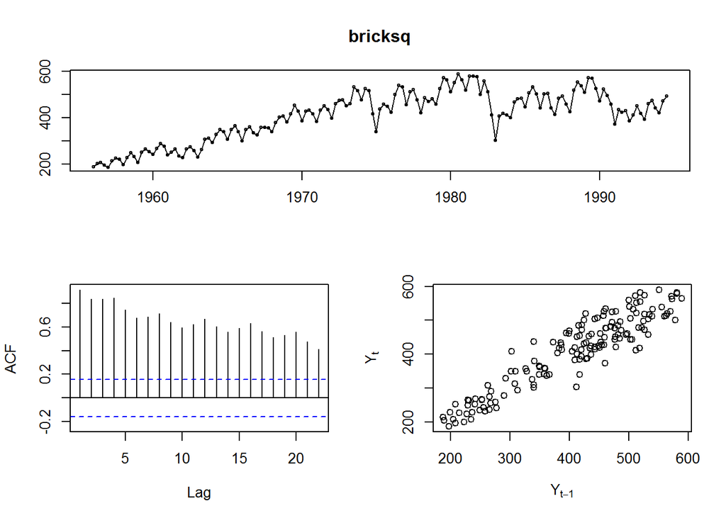

```r
tsdisplay(bricksq, plot.type="scatter")  #visų duomenų grafikas
```

Paėmus duomenis iki 1972, iš ACF grafiko matomas akivaizdus sezoniškumas, nes AFC kas 4 lag’us pasiekia piką. Kadangi matuotas ketvirčiais, praėjusių metų ketvirčiai geriausiai prognozuoja tuos pačius ketvirčius kitiem metam. Taip pat gęstantis AFC rodo trendo egzistavimą.

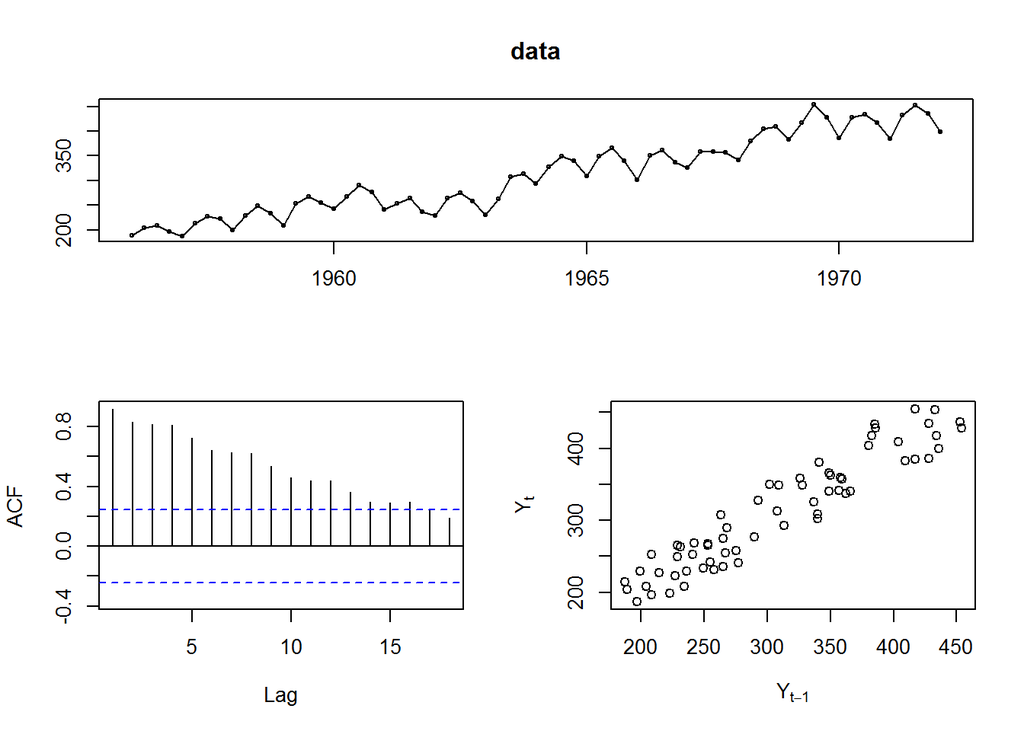

```r
data=window(bricksq,end=1972)            # iki 1972 duomenys
tsdisplay(data, plot.type="scatter")     # iki 1972 duomenų grafikas
```

bricksq duomenys. Paėmus duomenis nuo 1973, iš AFC grafiko matome, kad kovariacija apsivertė - iš teigiamo tapo neigiama ir pasiekia AFC žemumą kas 4 lag’us. Taigi yra sezoniškumas, dingo trendas, tačiau matomi cyklai.

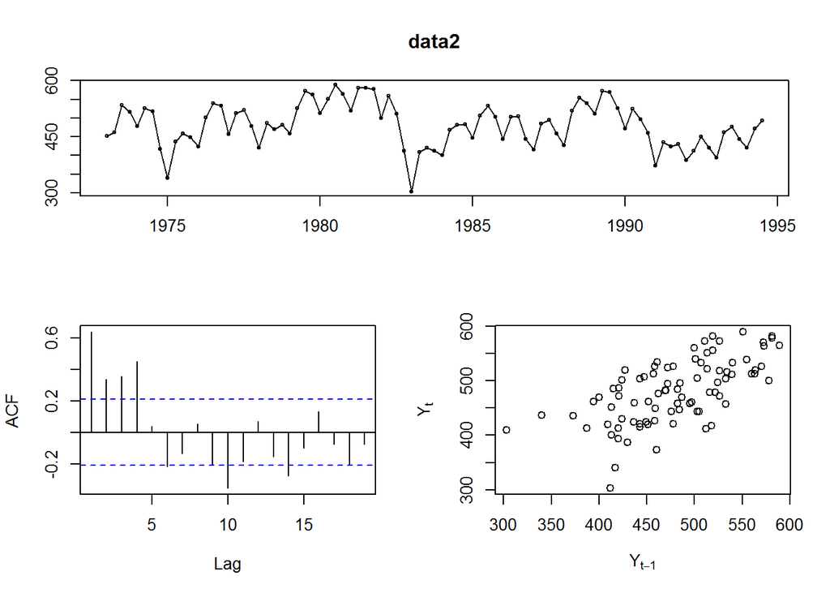

```r
data2=window(bricksq,start=1973)         #nuo 1973 duomenys
tsdisplay(data2, plot.type="scatter")    #nuo 1973 duomenų grafikas
```

hsales duomenys. Yra sezoniškumas pagal AFC, nėra trendo, bet yra cykliškumas.

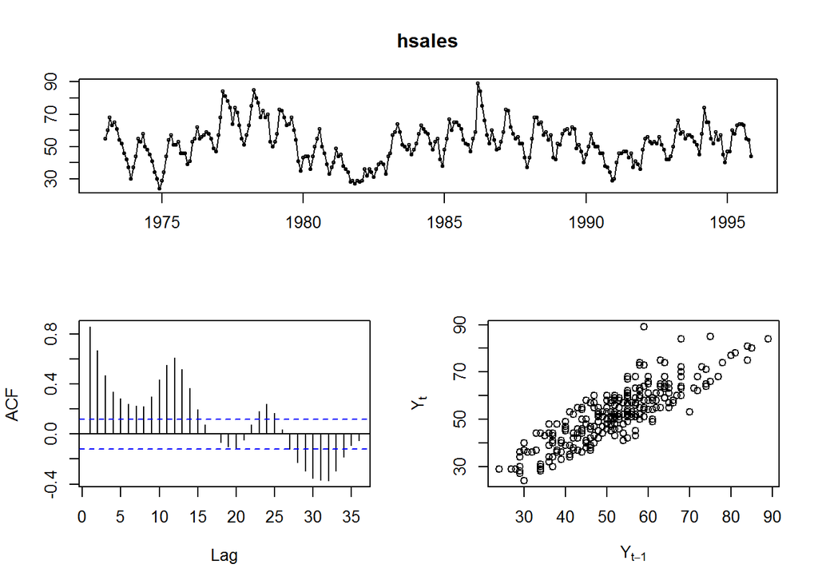

```r
tsdisplay(hsales, plot.type="scatter")   #visų duomenų grafikas
```

ibmclose duomenys.

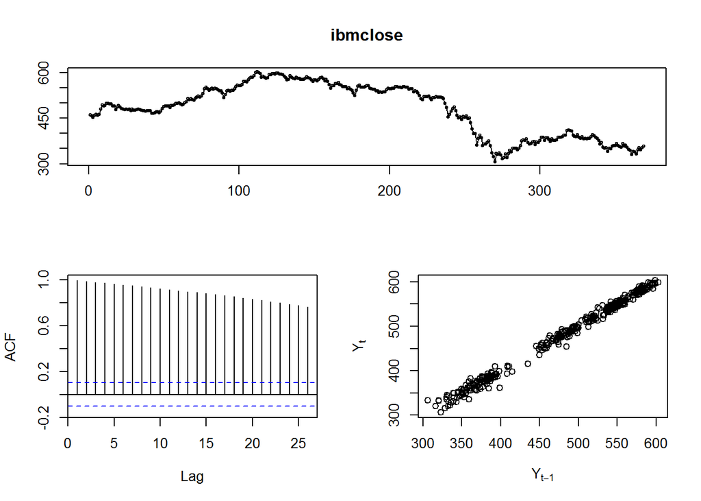

```r
tsdisplay(ibmclose, plot.type="scatter") #visų duomenų grafikas
```

Imant duomenis iki 200, egzistuoja trendas ir silpnas sezoniškumas, nėra cyklų. Iki maždaug 117 buvo kilimo trendas, o po 117 - kritimo trendas.

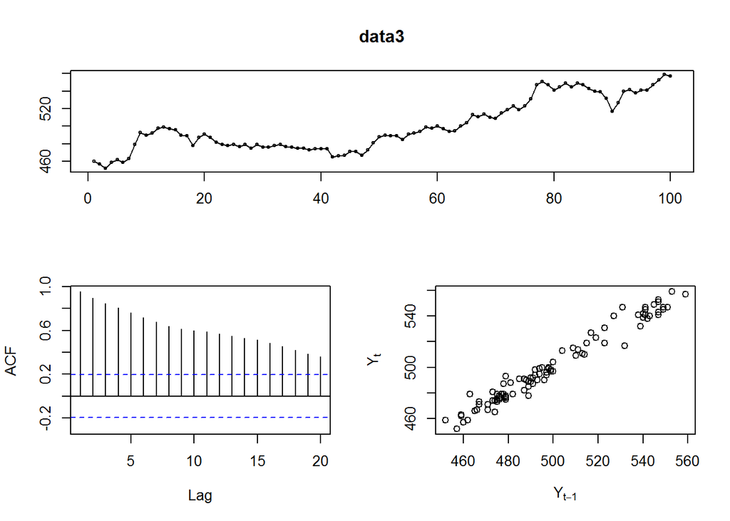

```r
data3=window(ibmclose,end=100)
data4=window(ibmclose,start=101,end=200)
tsdisplay(data3, plot.type="scatter")    # iki 100 duomenų grafikas
```

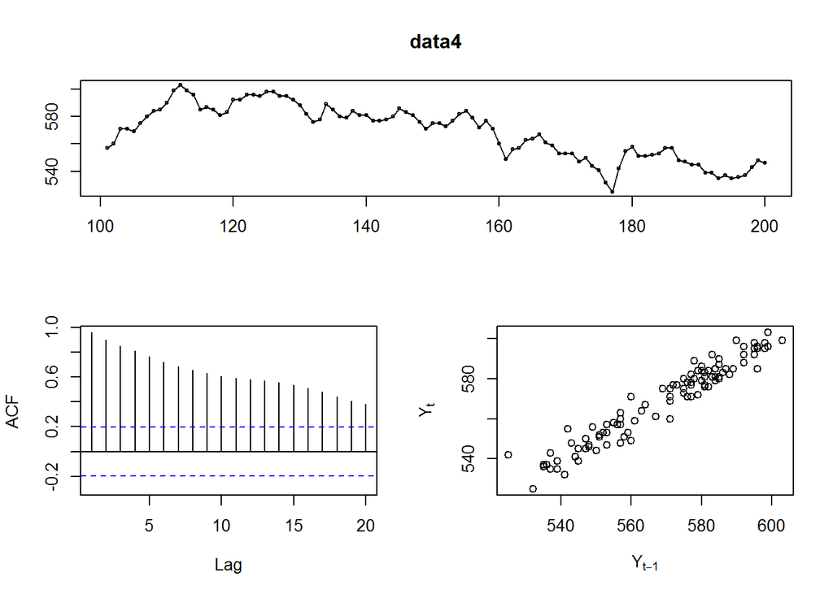

```r
tsdisplay(data4, plot.type="scatter")    # nuo 101 iki 200 duomenų grafikas
```

ibmclose duomenys. Duomenyse nuo 201 iki 275 dingsta sezoniškumas, išlieka kritimo trendas, atsiranda nežymių cyklų. Nuo 275 atsiranda vėl nežymus sezoniškumas.

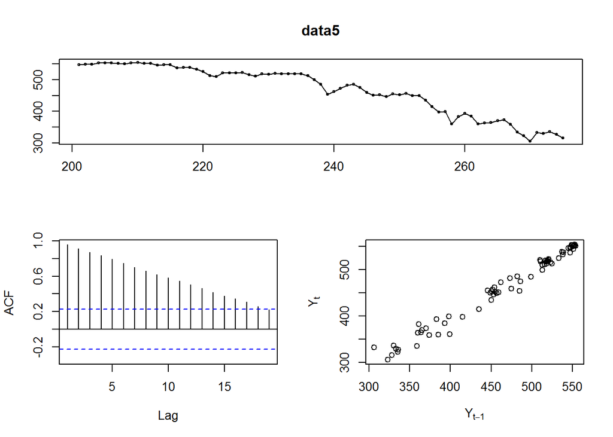

```r
data5=window(ibmclose,start=201, end=275)
data6=window(ibmclose,start=276)

tsdisplay(data5, plot.type="scatter")
```

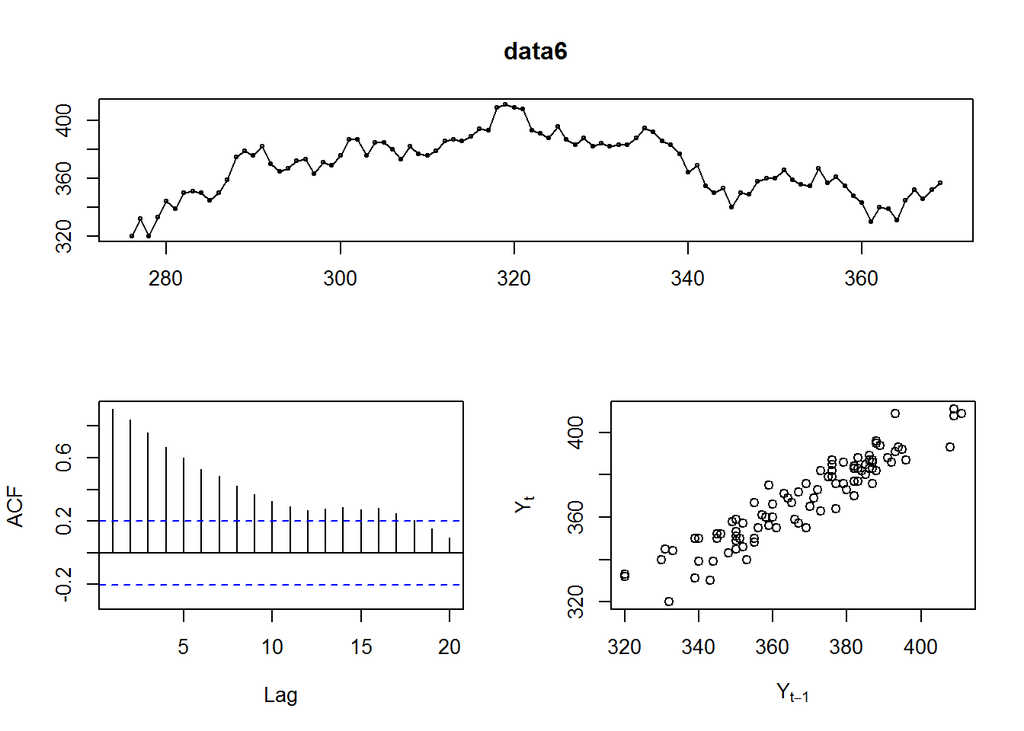

```r
tsdisplay(data6, plot.type="scatter")
```